# Final Project 1

Mohammad Hajjaj

2023-11-19

# 1 Exploratory Data Analysis (EDA):

## 1.1 Basic EDA

**Basic data overview**:

```r
head(df)
```

```
## # A tibble: 6 × 9
##       R     G     B Lightness Saturation   Hue response outcome logit_response
##   <dbl> <dbl> <dbl> <chr>     <chr>      <dbl>    <dbl>   <dbl>          <dbl>
## 1   172    58    62 dark      bright         4       12       1          -1.99
## 2    26    88   151 dark      bright        31       10       1          -2.20
## 3   172    94    58 dark      bright         8       16       1          -1.66
## 4    28    87   152 dark      bright        32       10       0          -2.20
## 5   170    66    58 dark      bright         5       11       0          -2.09
## 6   175    89    65 dark      bright         6       16       0          -1.66
```

**Quick summary statistics of the data set**:

```r
summary(df)
```

```
##        R               G               B          Lightness
##  Min.   :  0.0   Min.   : 58.0   Min.   : 47.0   Length:835
##  1st Qu.:147.0   1st Qu.:138.0   1st Qu.:112.5   Class :character
##  Median :203.0   Median :188.0   Median :170.0   Mode  :character
##  Mean   :183.3   Mean   :176.3   Mean   :160.3
##  3rd Qu.:229.5   3rd Qu.:222.0   3rd Qu.:211.0
##  Max.   :255.0   Max.   :241.0   Max.   :238.0
##   Saturation             Hue           response       outcome
##  Length:835         Min.   : 1.00   Min.   : 6.0   Min.   :0.0000
##  Class :character   1st Qu.: 9.00   1st Qu.:26.0   1st Qu.:0.0000
##  Mode  :character   Median :17.00   Median :51.0   Median :0.0000
##                     Mean   :17.68   Mean   :48.6   Mean   :0.2287
##                     3rd Qu.:26.00   3rd Qu.:72.0   3rd Qu.:0.0000
##                     Max.   :36.00   Max.   :87.0   Max.   :1.0000
##  logit_response
##  Min.   :-2.75154
##  1st Qu.:-1.04597
##  Median : 0.04001
##  Mean   :-0.10936
##  3rd Qu.: 0.94446
##  Max.   : 1.90096
```

**Quick data types check** :

```r
glimpse(df)
```

```
## Rows: 835
## Columns: 9
## $ R              <dbl> 172, 26, 172, 28, 170, 175, 90, 194, 171, 122, 0, 88, 1…
## $ G              <dbl> 58, 88, 94, 87, 66, 89, 78, 106, 68, 151, 121, 140, 82,…
## $ B              <dbl> 62, 151, 58, 152, 58, 65, 136, 53, 107, 59, 88, 58, 132…
## $ Lightness      <chr> "dark", "dark", "dark", "dark", "dark", "dark", "dark",…
## $ Saturation     <chr> "bright", "bright", "bright", "bright", "bright", "brig…
## $ Hue            <dbl> 4, 31, 8, 32, 5, 6, 34, 10, 1, 21, 24, 22, 36, 16, 26, …
## $ response       <dbl> 12, 10, 16, 10, 11, 16, 10, 19, 14, 25, 14, 19, 14, 38,…
## $ outcome        <dbl> 1, 1, 1, 0, 0, 0, 0, 0, 0, 0, 0, 0, 0, 0, 0, 0, 0, 0, 1…
## $ logit_response <dbl> -1.9924302, -2.1972246, -1.6582281, -2.1972246, -2.0907…
```

*All variables are of a continuous type except for Lightness and Saturation which are categorical variables*. Outcome, on the other hand is a binary variable coded as 0 and 1.

**Show summary for the different categories/groups for Lightness and Saturation**:

```r
df <- df |>
  mutate(across(c(Lightness, Saturation), as.factor))

df |> count(Lightness) |> mutate(prop = n / sum(n))
```

```
## # A tibble: 7 × 3
##   Lightness     n  prop
##   <fct>     <int> <dbl>
## 1 dark        117 0.140
## 2 deep        119 0.143
## 3 light       120 0.144
## 4 midtone     119 0.143
## 5 pale        121 0.145
## 6 saturated   119 0.143
## 7 soft        120 0.144
```

```r
df |> count(Saturation) |> mutate(prop = n / sum(n))
```

```
## # A tibble: 7 × 3
##   Saturation     n   prop
##   <fct>      <int>  <dbl>
## 1 bright       126 0.151
## 2 gray          83 0.0994
## 3 muted        126 0.151
## 4 neutral      122 0.146
## 5 pure         126 0.151
## 6 shaded       126 0.151
## 7 subdued      126 0.151
```

**Check for missing values**:

```r
map(df, ~sum(is.na(.)))
```

```
## $R
## [1] 0
##
## $G
## [1] 0
##
## $B
## [1] 0
##
## $Lightness
## [1] 0
##
## $Saturation
## [1] 0
##
## $Hue
## [1] 0
##
## $response
## [1] 0
##
## $outcome
## [1] 0
##
## $logit_response
## [1] 0
```

*Based on the missing values summary, we have a complete data set with no missing values for any column in the data frame*.

**Check for duplicated cases**:

```r
sum(duplicated(df))
```

```
## [1] 0
```

*Each row in the data set is unique and there is no duplicated ones*.

## 1.2 EDA for categorical variables (Lightness and Saturation):

Distribution of categorical variables using a bar chart.

### 1.2.1 Visualizing counts for ‘Lightness’

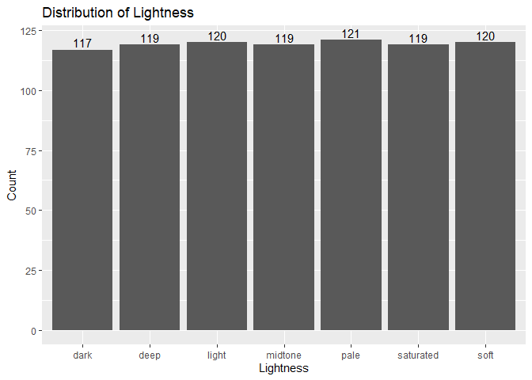

```r
df %>%
ggplot(aes(x = Lightness)) +
  geom_bar() +
  geom_text(stat='count', aes(label=..count..), vjust=-0.3) +
  labs(x = "Lightness", y = "Count", title = "Distribution of Lightness")
```

```r
# This table to show both the counts and proportions for each category
df |> count(Lightness) |> mutate(prop = n / sum(n))
```

```
## # A tibble: 7 × 3
##   Lightness     n  prop
##   <fct>     <int> <dbl>
## 1 dark        117 0.140
## 2 deep        119 0.143
## 3 light       120 0.144
## 4 midtone     119 0.143
## 5 pale        121 0.145
## 6 saturated   119 0.143
## 7 soft        120 0.144
```

*The lightness variable has 7 categories as shown on the X-axis and the proportion is kind of similar for all categories*.

### 1.2.2 Visualizing counts for ‘Saturation’

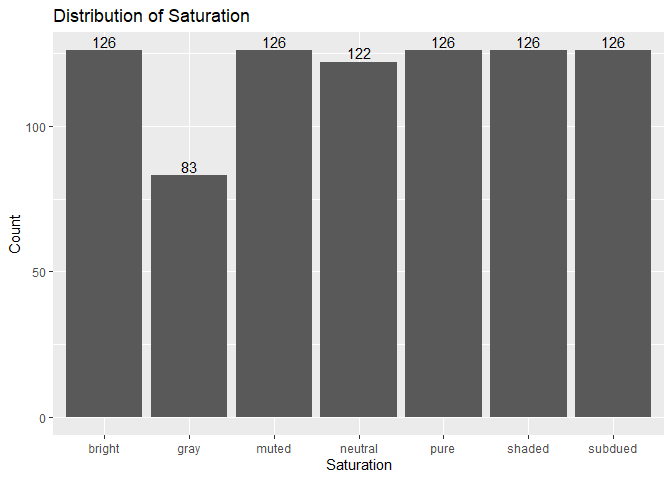

```r
df %>%
ggplot( aes(x = Saturation)) +
  geom_bar() +
  geom_text(stat='count', aes(label=..count..), vjust=-0.3) +
  labs(x = "Saturation", y = "Count", title = "Distribution of Saturation")
```

```r
# This table to show both the counts and proportions for each category
df |> count(Saturation) |> mutate(prop = n / sum(n))
```

```
## # A tibble: 7 × 3
##   Saturation     n   prop
##   <fct>      <int>  <dbl>
## 1 bright       126 0.151
## 2 gray          83 0.0994
## 3 muted        126 0.151
## 4 neutral      122 0.146
## 5 pure         126 0.151
## 6 shaded       126 0.151
## 7 subdued      126 0.151
```

*Saturation has 7 categories with gray as the least frequent group*.

## 1.3 EDA for continuous variables (R, G, B, Hue, Response):

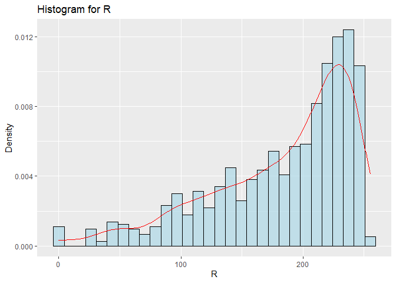

```r
ggplot(df, aes(x = R)) +
  geom_histogram(aes(y = ..density..), bins = 30, fill = "lightblue", color = "black", alpha = 0.7) +
  geom_density(color = "red") +
  labs(title = "Histogram for R", x = "R", y = "Density")
```

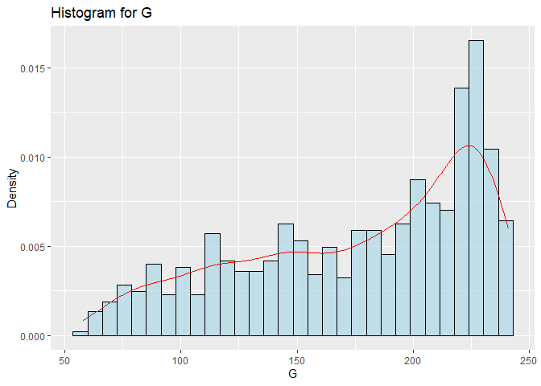

```r
ggplot(df, aes(x = G)) +
  geom_histogram(aes(y = ..density..), bins = 30, fill = "lightblue", color = "black", alpha = 0.7) +
  geom_density(color = "red") +
  labs(title = "Histogram for G", x = "G", y = "Density")
```

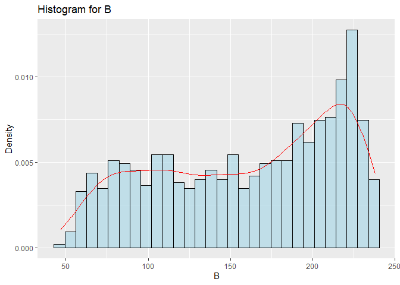

```r
ggplot(df, aes(x = B)) +
  geom_histogram(aes(y = ..density..), bins = 30, fill = "lightblue", color = "black", alpha = 0.7) +
  geom_density(color = "red") +
  labs(title = "Histogram for B", x = "B", y = "Density")
```

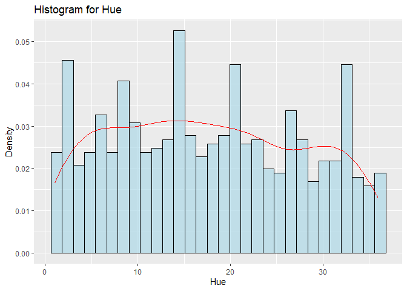

```r
ggplot(df, aes(x = Hue)) +
  geom_histogram(aes(y = ..density..), bins = 30, fill = "lightblue", color = "black", alpha = 0.7) +
  geom_density(color = "red") +
  labs(title = "Histogram for Hue", x = "Hue", y = "Density")
```

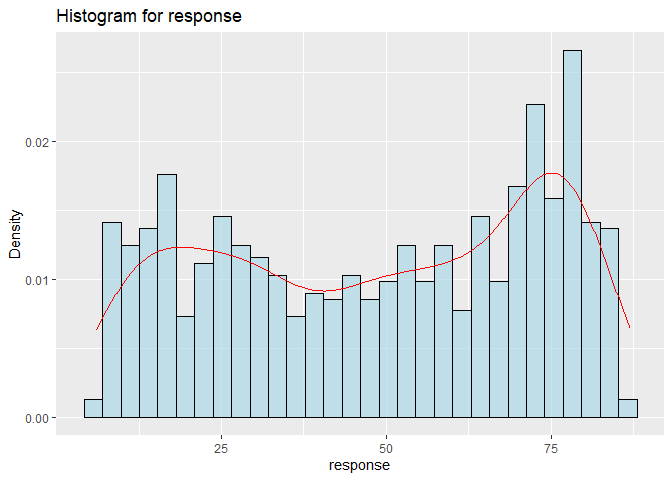

```r
ggplot(df, aes(x = response)) +
  geom_histogram(aes(y = ..density..), bins = 30, fill = "lightblue", color = "black", alpha = 0.7) +
  geom_density(color = "red") +
  labs(title = "Histogram for response", x = "response", y = "Density")
```

**Based on all of the above**:

*The different visuals for R, G, B, Hue, and response variables indicate that none of them have Gaussian-like distributions*.  
*These variables exhibit skewness, multi-modal patterns, or non-uniformity in their distributions, which deviate from the typical bell-shaped curve of normal distributions*.

### 1.3.1 Continuous variables conditioned on categorical variables

Find below the boxplots for the continuous variables conditioned on the categorical variables. Each box plot shows the distribution of the continuous variable and represents a summary statistics that entails the median, the interquartile range, and the range of the data. The boxplots are also colored by the categorical variables to show the distribution of the continuous variables across the different categories of the categorical variables.

#### 1.3.1.1 R

##### 1.3.1.1.1 R by Lightness

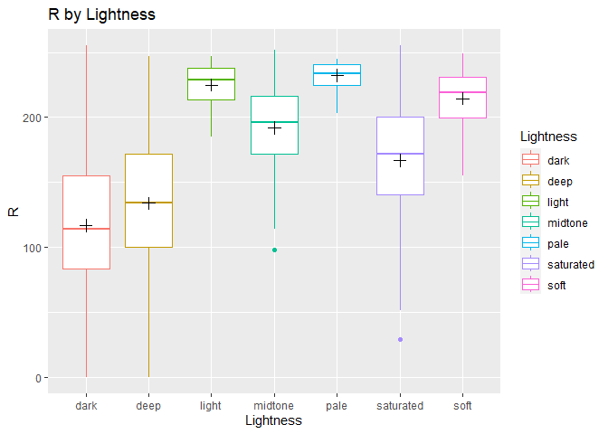

```r
df %>%
ggplot(aes(x = Lightness, y = R)) +
              geom_boxplot(aes(color = Lightness)) +
  labs(title = "R by Lightness", x = "Lightness", y = "R") +
    stat_summary(fun = mean, geom = "point", shape = 3,
                 size = 3, color = "black",
                 position = position_dodge(width = 0.75))
```

The average R values for light, midtone, pale, and soft categories are higher than the average R values for dark, deep, and saturated categories. The average R value for the dark category is the lowest among all categories.

##### 1.3.1.1.2 R by Saturation

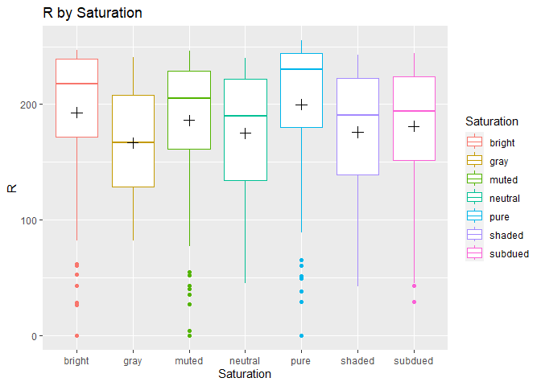

```r
df %>%
ggplot(aes(x = Saturation, y = R)) +
              geom_boxplot(aes(color = Saturation)) +
  labs(title = "R by Saturation", x = "Saturation", y = "R") +
    stat_summary(fun = mean, geom = "point", shape = 3,
                 size = 3, color = "black",
                 position = position_dodge(width = 0.75))
```

The average R values for the categories are overlapping and there is no clear pattern.

##### 1.3.1.1.3 R by outcome

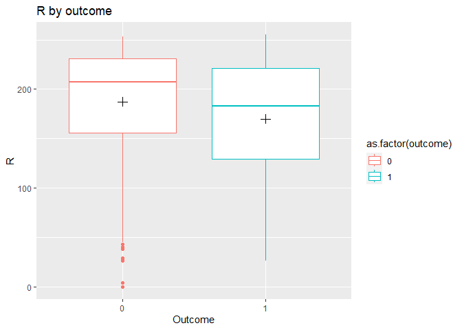

```r
df %>%
ggplot(aes(x = as.factor(outcome), y = R)) +
              geom_boxplot(aes(color = as.factor(outcome))) +
  labs(title = "R by outcome", x = "Outcome", y = "R") +
    stat_summary(fun = mean, geom = "point", shape = 3,
                 size = 3, color = "black",
                 position = position_dodge(width = 0.75))
```

The average and median R value for the 0 category are higher than the average and median R value for the 1 category.

#### 1.3.1.2 G

##### 1.3.1.2.1 G by Lightness

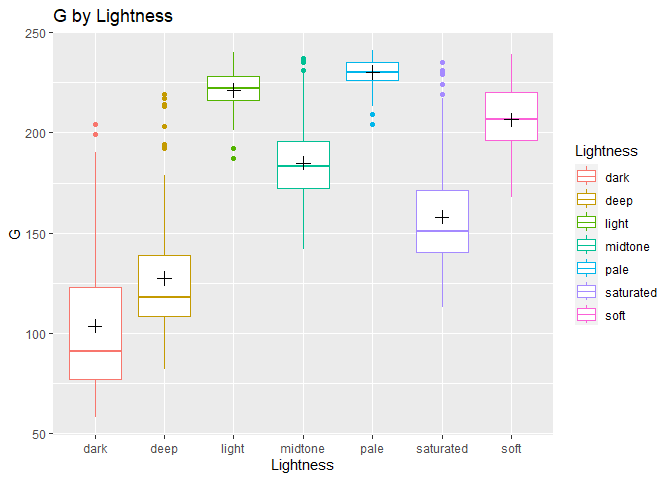

```r
df %>%
ggplot(aes(x = Lightness, y = G)) +
              geom_boxplot(aes(color = Lightness)) +
  labs(title = "G by Lightness", x = "Lightness", y = "G") +
    stat_summary(fun = mean, geom = "point", shape = 3,
                 size = 3, color = "black",
                 position = position_dodge(width = 0.75))
```

The average G values for light, midtone, pale, and soft categories are higher than the average G values for dark, deep, and saturated categories. The average G value for the dark category is the lowest among all categories.

##### 1.3.1.2.2 G by Saturation

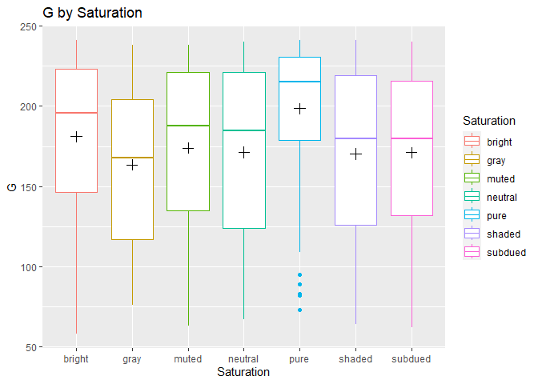

```r
df %>%
ggplot(aes(x = Saturation, y = G)) +
              geom_boxplot(aes(color = Saturation)) +
  labs(title = "G by Saturation", x = "Saturation", y = "G") +
    stat_summary(fun = mean, geom = "point", shape = 3,
                 size = 3, color = "black",
                 position = position_dodge(width = 0.75))
```

The average R values for the categories are overlapping and there is no clear pattern. The highest average and median is for the pure category. The lowest average and median is for the gray category.

##### 1.3.1.2.3 G by outcome

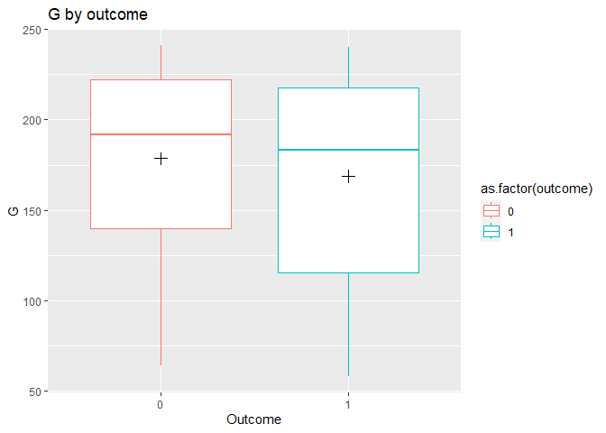

```r
df %>%
ggplot(aes(x = as.factor(outcome), y = G)) +
              geom_boxplot(aes(color = as.factor(outcome))) +
  labs(title = "G by outcome", x = "Outcome", y = "G") +
    stat_summary(fun = mean, geom = "point", shape = 3,
                 size = 3, color = "black",
                 position = position_dodge(width = 0.75))
```

The average and median G value for the 0 category are higher than the average and median G value for the 1 category.

#### 1.3.1.3 B

##### 1.3.1.3.1 B by Lightness

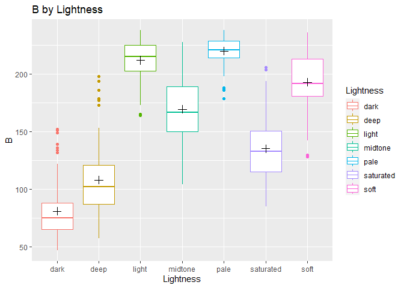

```r
df %>%
ggplot(aes(x = Lightness, y = B)) +
              geom_boxplot(aes(color = Lightness)) +
  labs(title = "B by Lightness", x = "Lightness", y = "B") +
    stat_summary(fun = mean, geom = "point", shape = 3,
                 size = 3, color = "black",
                 position = position_dodge(width = 0.75))
```

The average B values for light, midtone, pale, and soft categories are higher than the average B values for dark, deep, and saturated categories. The average B value for the dark category is the lowest among all categories.

##### 1.3.1.3.2 B by Saturation

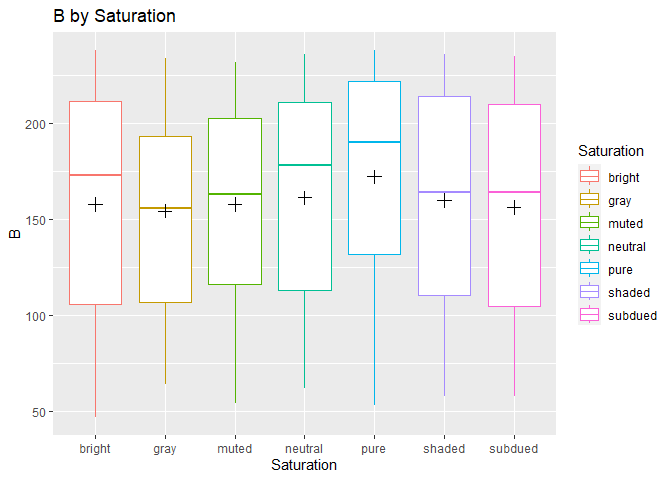

```r
df %>%
ggplot(aes(x = Saturation, y = B)) +
              geom_boxplot(aes(color = Saturation)) +
  labs(title = "B by Saturation", x = "Saturation", y = "B") +
    stat_summary(fun = mean, geom = "point", shape = 3,
                 size = 3, color = "black",
                 position = position_dodge(width = 0.75))
```

The avaerage B values for the categories are overlapping and there is no clear pattern. The highest average and median is for the pure category. The lowest average and median is for the gray category.

##### 1.3.1.3.3 B by outcome

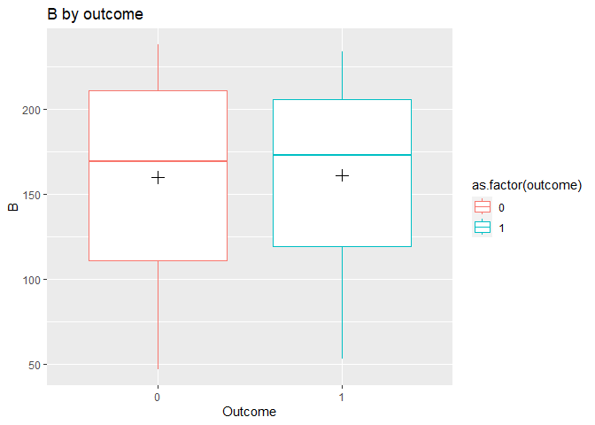

```r
df %>%
ggplot(aes(x = as.factor(outcome), y = B)) +
              geom_boxplot(aes(color = as.factor(outcome))) +
  labs(title = "B by outcome", x = "Outcome", y = "B") +
    stat_summary(fun = mean, geom = "point", shape = 3,
                 size = 3, color = "black",
                 position = position_dodge(width = 0.75))
```

The average and median B value for the 0 category is kind of similar to the median B value for the 1 category.

#### 1.3.1.4 Hue

##### 1.3.1.4.1 Hue by Lightness

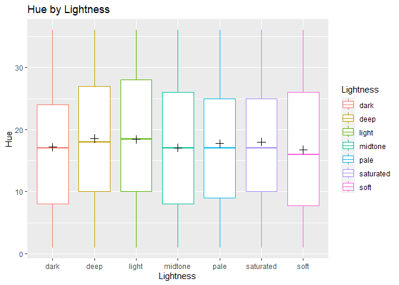

```r
df %>%
ggplot(aes(x = Lightness, y = Hue)) +
              geom_boxplot(aes(color = Lightness)) +
  labs(title = "Hue by Lightness", x = "Lightness", y = "Hue") +
    stat_summary(fun = mean, geom = "point", shape = 3,
                 size = 3, color = "black",
                 position = position_dodge(width = 0.75))
```

The average Hue values for light are kind of similar and there is no clear difference between them.

##### 1.3.1.4.2 Hue by Saturation

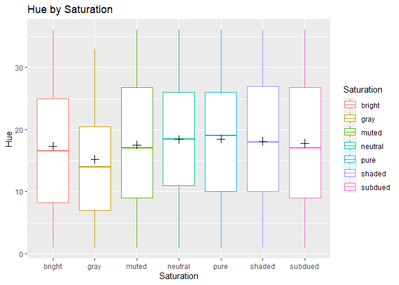

```r
df %>%
ggplot(aes(x = Saturation, y = Hue)) +
              geom_boxplot(aes(color = Saturation)) +
  labs(title = "Hue by Saturation", x = "Saturation", y = "Hue") +
    stat_summary(fun = mean, geom = "point", shape = 3,
                 size = 3, color = "black",
                 position = position_dodge(width = 0.75))
```

The average Hue values for the categories are overlapping and there is no clear pattern. The highest average and median is for the pure category. The lowest average and median is for the gray category.

##### 1.3.1.4.3 Hue by outcome

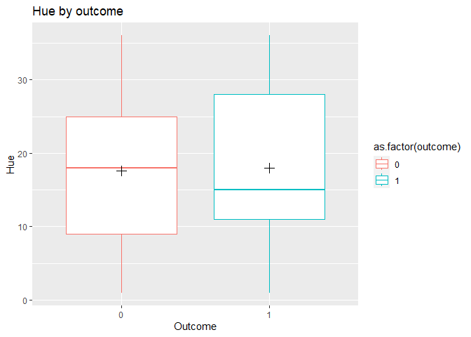

```r
df %>%
ggplot(aes(x = as.factor(outcome), y = Hue)) +
              geom_boxplot(aes(color = as.factor(outcome))) +
  labs(title = "Hue by outcome", x = "Outcome", y = "Hue") +
    stat_summary(fun = mean, geom = "point", shape = 3,
                 size = 3, color = "black",
                 position = position_dodge(width = 0.75))
```

The average Hue value for both outcomes is kind of the same. On the other hand, the median Hue value for the 0 category is higher than the median Hue value for the 1 category.

#### 1.3.1.5 Response

##### 1.3.1.5.1 Response by Lightness

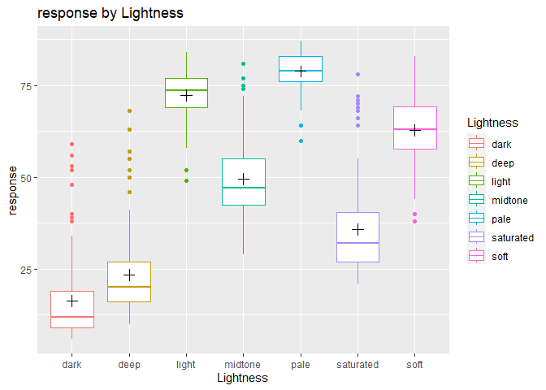

```r
df %>%
ggplot(aes(x = Lightness, y = response)) +
              geom_boxplot(aes(color = Lightness)) +
  labs(title = "response by Lightness", x = "Lightness", y = "response") +
    stat_summary(fun = mean, geom = "point", shape = 3,
                 size = 3, color = "black",
                 position = position_dodge(width = 0.75))
```

The average response values for light, midtone, pale, and soft categories are higher than the average response values for dark, deep, and saturated categories. The average response value for the dark category is the lowest among all categories.

##### 1.3.1.5.2 Response by Saturation

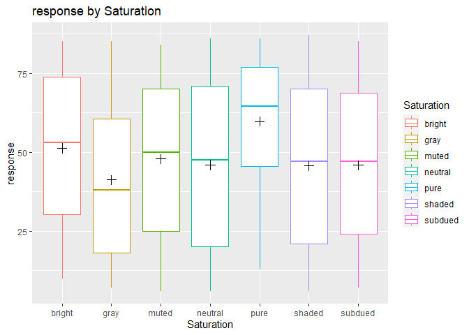

```r
df %>%
ggplot(aes(x = Saturation, y = response)) +
              geom_boxplot(aes(color = Saturation)) +
  labs(title = "response by Saturation", x = "Saturation", y = "response") +
    stat_summary(fun = mean, geom = "point", shape = 3,
                 size = 3, color = "black",
                 position = position_dodge(width = 0.75))
```

The average response values for the categories are overlapping and there is no clear pattern. The highest average and median is for the pure category. The lowest average and median is for the gray category.

##### 1.3.1.5.3 Response by outcome

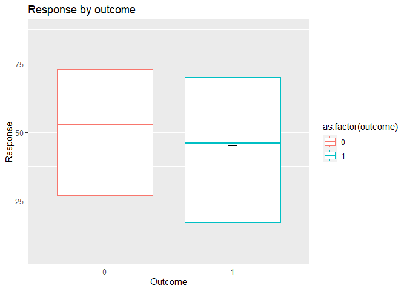

```r
df %>%
ggplot(aes(x = as.factor(outcome), y = response)) +
              geom_boxplot(aes(color = as.factor(outcome))) +
  labs(title = "Response by outcome", x = "Outcome", y = "Response") +
    stat_summary(fun = mean, geom = "point", shape = 3,
                 size = 3, color = "black",
                 position = position_dodge(width = 0.75))
```

The average and median response value for the 0 category is kind of similar to the median response value for the 1 category.

### 1.3.2 Correlation between continuous variables

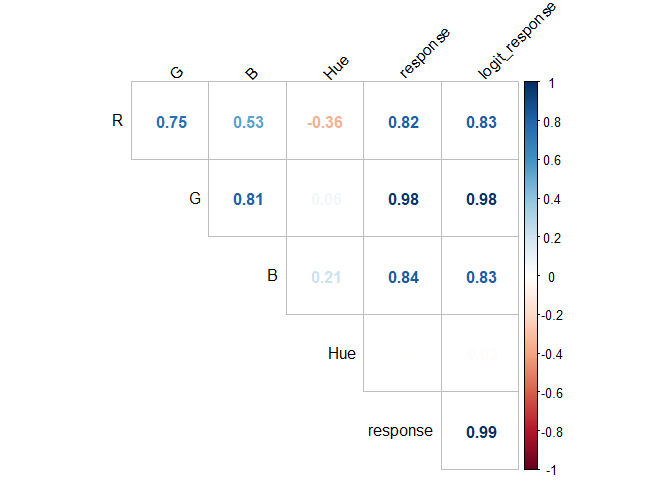

```r
library(corrplot)
library(magrittr)
library(psych)

df |>
  select_if(is.numeric) |>
  select(-outcome) |>
  cor() |>
  corrplot(type = "upper", method = "number",
           tl.col = "black", tl.srt = 45, diag = FALSE)
```

**Based on the shown correlation matrix, we can clearly see that our response variable is highly correlated with R, G, and B with correlation values of 0.82, 0.98, and 0.84 respectively. At the same time R, G, and B are highly correlated with each others. Note that response is not correlated with Hue as the matrix shows**.

### 1.3.3 Response variable vs. R, G, B and Hue

#### 1.3.3.1 Response

##### 1.3.3.1.1 Response vs. R

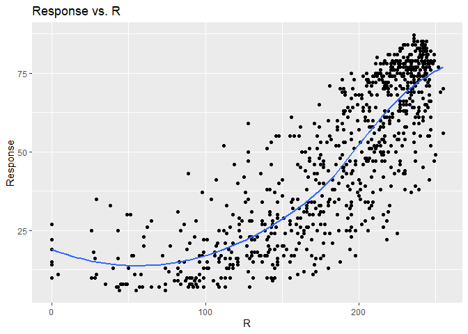

```r
df |>
  ggplot(aes(x = R, y = response)) +
  geom_point() +
  labs(title = "Response vs. R", x = "R", y = "Response") +
  geom_smooth(method = 'loess',formula = 'y ~ x', se = FALSE)
```

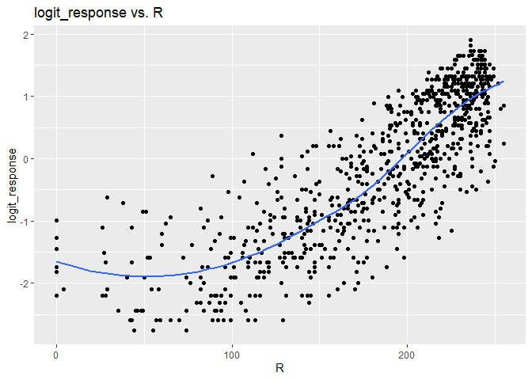

```r
df |>
  ggplot(aes(x = R, y = logit_response)) +
  geom_point() +
  labs(title = "logit_response vs. R", x = "R", y = "logit_response") +
  geom_smooth(method = 'loess',formula = 'y ~ x', se = FALSE)
```

Both the response and the logit response variables are highly and positively correlated with R. The response variable increases as R increases but the relationship seems to be quadratic in this plot.

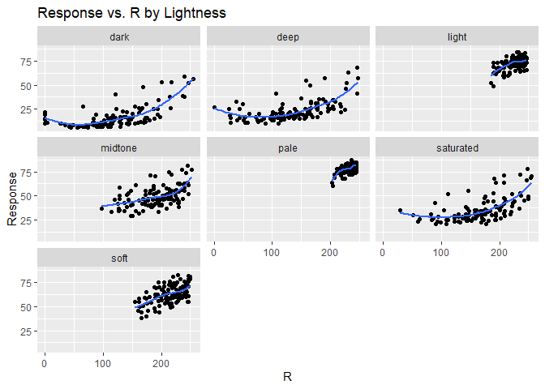

```r
df |>
  ggplot(aes(x = R, y = response)) +
  geom_point() +
  labs(title = "Response vs. R by Lightness", x = "R", y = "Response") +
  geom_smooth(method = 'loess',formula = 'y ~ x', se = FALSE) +
  facet_wrap(~ Lightness)
```

Based on the shown plot, the response variable increases as R increases for all lightness categories. Both light and pale categories have the highest response and R values. The relationship seems to be quadratic for dark, deep, and saturated categories.

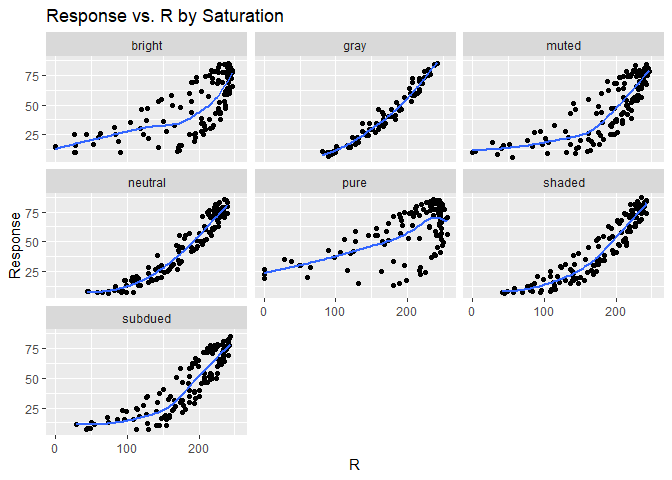

```r
df |>
  ggplot(aes(x = R, y = response)) +
  geom_point() +
  labs(title = "Response vs. R by Saturation", x = "R", y = "Response") +
  geom_smooth(method = 'loess',formula = 'y ~ x', se = FALSE) +
  facet_wrap(~ Saturation)
```

##### 1.3.3.1.2 Response vs. G

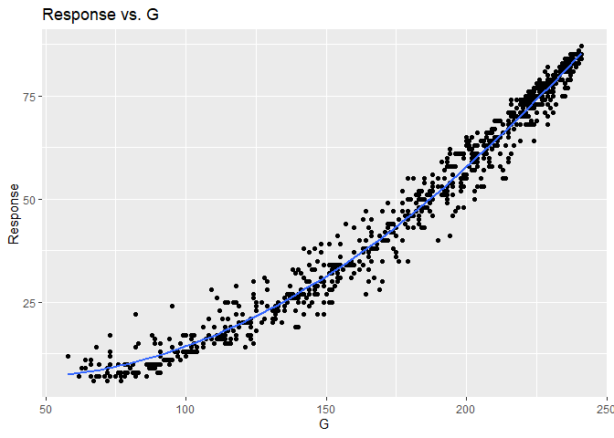

```r
df |>
  ggplot(aes(x = G, y = response)) +
  geom_point() +
  labs(title = "Response vs. G", x = "G", y = "Response") +
  geom_smooth(method = 'loess',formula = 'y ~ x', se = FALSE)
```

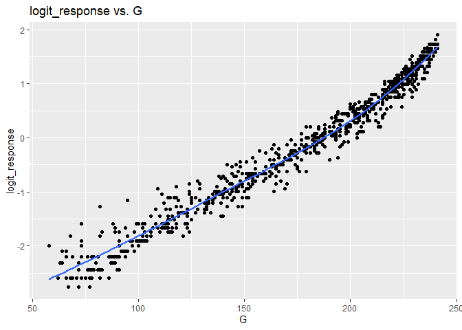

```r
df |>
  ggplot(aes(x = G, y = logit_response)) +
  geom_point() +
  labs(title = "logit_response vs. G", x = "G", y = "logit_response") +
  geom_smooth(method = 'loess',formula = 'y ~ x', se = FALSE)
```

Both the response and the logit response variables are highly and positively correlated with G. The response variable increases as G increases.

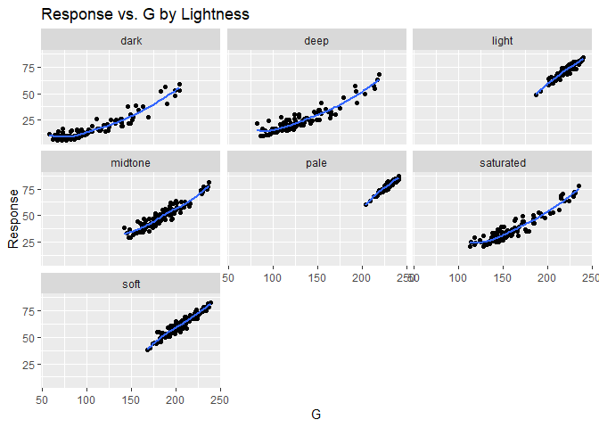

```r
df |>
  ggplot(aes(x = G, y = response)) +
  geom_point() +
  labs(title = "Response vs. G by Lightness", x = "G", y = "Response") +
  geom_smooth(method = 'loess',formula = 'y ~ x', se = FALSE) +
  facet_wrap(~ Lightness)
```

Based on the shown plot, the response variable increases as G increases for all lightness categories. Both light and pale categories have the highest response and G values.

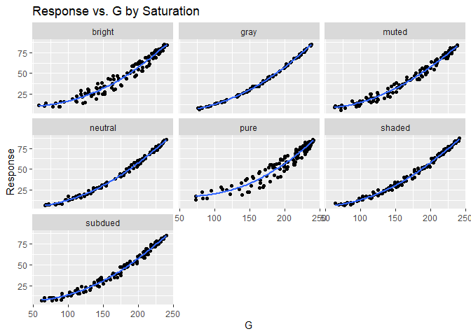

```r
df |>
  ggplot(aes(x = G, y = response)) +
  geom_point() +
  labs(title = "Response vs. G by Saturation", x = "G", y = "Response") +
  geom_smooth(method = 'loess',formula = 'y ~ x', se = FALSE) +
  facet_wrap(~ Saturation)
```

Based on the shown plot, the response variable increases as G increases for all saturation categories. The relationship seems to be quadratic for all the categories.